# Homework 1

Yuki Joyama

2023-09-23

# Problem 1

1. Qualitative, ordinal
2. Qualitative, binary
3. Qualitative, ordinal
4. Quantitative, continuous
5. Quantitative, discrete

# Problem 2

The depression scores for 14 individuals with a recent bike crash history (I will define this as group A):  
45, 39, 25, 47, 49, 5, 70, 99, 74, 37, 99, 35, 8, 59

1. Descriptive summaries

Mean: $\sum_{i=1}^{14}\frac{x_i}{14}$ = 49.36  
Median: $(45+47)/2$ = 46  
Range: $99-5$ = 94  
SD: $\sqrt{\frac{1}{14-1} \sum_{i=1}^{14} (x_i - \overline{x})^2}$ = 28.85

2. Box plot of the depression scores of group A

The box plot and histogram (plot not shown) indicate right-skewed, unimodal distribution.

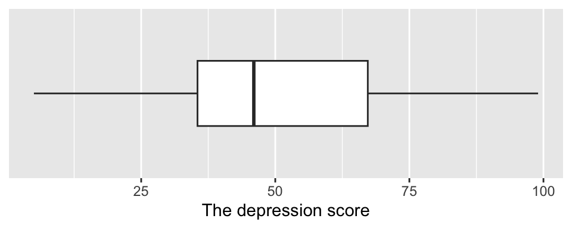

The depression scores for 13 individuals with a recent car crash history (I will define this as group B):  
67, 50, 85, 43, 64, 35, 47, 97, 58, 58, 10, 56, 50

1. Side-by-side box plot of the depression scores stratified by type of accident

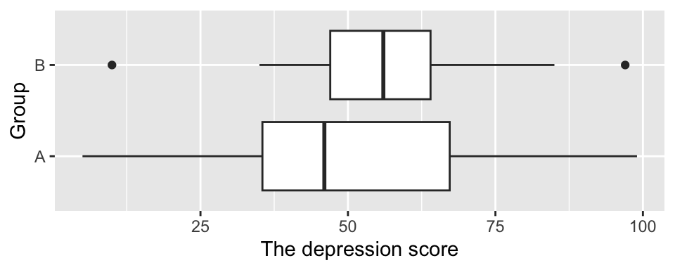

2. Based on the box plot and histogram (plot not shown), group A appears to have right-skewed, unimodal distribution while group B has left-skewed, unimodal distribution. This is also supported by the fact mean > median in group A and mean < median in group B.
3. Judging from the box plot, group A appears to have a lower typical depression score.

# Problem 3

Tossing one fair 12-sided die.

1. event A: an even number appears  
   Let $\Omega$ = {1, 2, …, 12}  
   Let A = {2, 4, 6, 8, 10, 12}, $A \subset \Omega$  
   P(A) = $\frac{6}{12}$ = $\frac{1}{2}$
2. event B: number 10 appears Let $\Omega$ = {1, 2, …, 12}  
   Let B = {10}, $A \subset \Omega$  
   P(B) = $\frac{1}{12}$
3. $P(B \cup A)= P(A) + P(B) - P(B \cap A)$  
   $P(B \cap A)$ is the probability of number 10 appears (which is also an even number), so $P(B \cap A) = \frac{1}{12}$  
   Therefore, $P(B \cup A)= P(A) + P(B) - P(B \cap A)=\frac{1}{2}+\frac{1}{12}-\frac{1}{12}=\frac{1}{2}$
4. If event A and event B are independent, $P(A \cap B)$ should be equal to $P(A) P(B)$.  
   Now, given $P(A) P(B)=\frac{1}{2}\times\frac{1}{12}=\frac{1}{24}\neq P(A \cap B)$, we can say that these two events are not independent.

# Problem 4

Let A be having dementia and B be having positive CT scan findings.  
5% of 75+ year-old women have dementia so $P(A)=0.05$  
Among women with dementia, 80% have positive CT scan findings so $P(B|A)=\frac{P(B\cap A)}{P(A)}=0.8$  
Given $P(A)=0.05$, $P(A\cap B)=0.04$  
10% showed a positive CT scan findings among women who don’t have dementia, and this gives $P(B|\bar{A})=\frac{P(B\cap \bar{A})}{P(\bar{A})}=0.1$  
Given $P(\bar{A})=1-0.05=0.95$, $P(B\cap \bar{A})=0.095$  
Now, $P(B)=P(A\cap B)+P(\bar{A} \cap B)=0.04+0.095=0.135$  
Therefore, the probability of a woman with a positive CT scan findings to have dementia is $P(A|B)=\frac{P(A\cap B)}{P(B)}=\frac{0.04}{0.135}=0.30$

The answer to this question would be 30%.